# Assignment 2: Electricity Market Prices

In this document, Market Clearing Price (PTF) - System Marginal Price (SMF) data shared on EPİAŞ Reporting Page is used. In addition to these two data, there are Positive Unbalance Price and Negative Unbalance Price data in the raw data.

**Market Clearing Price (PTF):**It can be called the price that occurs at the intersection of supply and demand as a result of bids made in the day ahead market.

**System Marginal Price (SMF):** In cases where the system shows an energy deficit or excess, it can be called the bid price corresponding to the net order volume.

**Positive Unbalance Price (PDF):** When there is an excess of energy in the system, it can be considered as the price value that enables the energy to be extracted cheaper than normal.

**Negative Unbalance Price (NDF):** When there is an energy deficit in the system, it can be considered as the price value that enables energy to be bought more expensive than normal.

For more detailed information, you can visit the [EPİAŞ](https://www.epias.com.tr/spot-elektrik-piyasasi) website.

> Contents of raw data:

```r
ptfsmf %>% glimpse()
```

```
## Rows: 744
## Columns: 6
## $ Date                              <chr> "01.07.20 00:00", "01.07.20 01:00...
## $ MCP.                              <dbl> 323.85, 326.95, 324.31, 322.11, 3...
## $ SMP.                              <dbl> 211.00, 201.00, 211.00, 211.00, 2...
## $ Positive.Imbalance.Price..TL.MWh. <dbl> 204.67, 194.97, 204.67, 204.67, 1...
## $ Negative.Imbalance.Price..TL.MWh. <dbl> 333.57, 336.76, 334.04, 331.77, 3...
## $ SMP.Direction                     <chr> "?Energy Surplus", "?Energy Surpl...
```

> Editing the Data

The first step, “Dates” column is char format, so this is converted, and also other columns converted to right format.

```r
ptfsmf$Date <- as.POSIXct(ptfsmf$Date, format="%d.%m.%y %H:%M")
```

Column names are updated, to easily understand.

```r
colnames(ptfsmf)[1] = "Date"
colnames(ptfsmf)[2] = "MCP"
colnames(ptfsmf)[3] = "SMP"
colnames(ptfsmf)[4] = "Positive.Imbalanca.Price"
colnames(ptfsmf)[5] = "Negative.Imbalance.Price"
colnames(ptfsmf)[6] = "SMP.Direction"
data_frame <-ptfsmf %>% transmute(Date, MCP, SMP, Positive.Imbalanca.Price, Negative.Imbalance.Price, SMP.Direction)
```

> Contents of updated data:

```r
ptfsmf %>% glimpse()
```

```
## Rows: 744
## Columns: 6
## $ Date                     <dttm> 2020-07-01 00:00:00, 2020-07-01 01:00:00,...
## $ MCP                      <dbl> 323.85, 326.95, 324.31, 322.11, 320.00, 28...
## $ SMP                      <dbl> 211.00, 201.00, 211.00, 211.00, 201.00, 18...
## $ Positive.Imbalanca.Price <dbl> 204.67, 194.97, 204.67, 204.67, 194.97, 17...
## $ Negative.Imbalance.Price <dbl> 333.57, 336.76, 334.04, 331.77, 329.60, 29...
## $ SMP.Direction            <chr> "?Energy Surplus", "?Energy Surplus", "?En...
```

> The data:

The head of the data…

```
##                  Date    MCP SMP Positive.Imbalanca.Price
## 1 2020-07-01 00:00:00 323.85 211                   204.67
## 2 2020-07-01 01:00:00 326.95 201                   194.97
## 3 2020-07-01 02:00:00 324.31 211                   204.67
## 4 2020-07-01 03:00:00 322.11 211                   204.67
## 5 2020-07-01 04:00:00 320.00 201                   194.97
## 6 2020-07-01 05:00:00 286.21 181                   175.57
##   Negative.Imbalance.Price   SMP.Direction
## 1                   333.57 ?Energy Surplus
## 2                   336.76 ?Energy Surplus
## 3                   334.04 ?Energy Surplus
## 4                   331.77 ?Energy Surplus
## 5                   329.60 ?Energy Surplus
## 6                   294.80 ?Energy Surplus
```

The tail of the data…

```
##                    Date    MCP    SMP Positive.Imbalanca.Price
## 739 2020-07-31 18:00:00 310.78 206.18                   199.99
## 740 2020-07-31 19:00:00 317.79 260.00                   252.20
## 741 2020-07-31 20:00:00 324.94 205.00                   198.85
## 742 2020-07-31 21:00:00 325.98 266.98                   258.97
## 743 2020-07-31 22:00:00 325.07 340.07                   315.32
## 744 2020-07-31 23:00:00 321.78 210.00                   203.70
##     Negative.Imbalance.Price    SMP.Direction
## 739                   320.10  ?Energy Surplus
## 740                   327.32  ?Energy Surplus
## 741                   334.69  ?Energy Surplus
## 742                   335.76  ?Energy Surplus
## 743                   350.27 ? Energy Deficit
## 744                   331.43  ?Energy Surplus
```

> Data Analysis

Here is the summary of the data.

```
##       Date                          MCP             SMP
##  Min.   :2020-07-01 00:00:00   Min.   :140.0   Min.   : 10.0
##  1st Qu.:2020-07-08 17:45:00   1st Qu.:300.0   1st Qu.:250.0
##  Median :2020-07-16 11:30:00   Median :306.6   Median :320.0
##  Mean   :2020-07-16 11:30:00   Mean   :296.4   Mean   :299.3
##  3rd Qu.:2020-07-24 05:15:00   3rd Qu.:317.0   3rd Qu.:345.0
##  Max.   :2020-07-31 23:00:00   Max.   :350.0   Max.   :460.0
##  Positive.Imbalanca.Price Negative.Imbalance.Price SMP.Direction
##  Min.   :  9.7            Min.   :144.2            Length:744
##  1st Qu.:228.2            1st Qu.:312.9            Class :character
##  Median :293.4            Median :331.9            Mode  :character
##  Mean   :268.6            Mean   :328.3
##  3rd Qu.:304.1            3rd Qu.:355.4
##  Max.   :339.5            Max.   :473.8
```

You can observe number of every single SMP Directions and total percentages in whole dataset.

```r
direction_df <- data_frame %>% group_by(SMP.Direction) %>% summarise(Count=n()) %>% mutate(Proportion=round(Count/sum(Count),2))
direction_df
```

```
## # A tibble: 3 x 3
##   SMP.Direction    Count Proportion
##   <chr>            <int>      <dbl>
## 1 ? Energy Deficit   528       0.71
## 2 ? In Balance        21       0.03
## 3 ?Energy Surplus    195       0.26
```

Here is the proportional pie chart of the groups in SMP Directions.

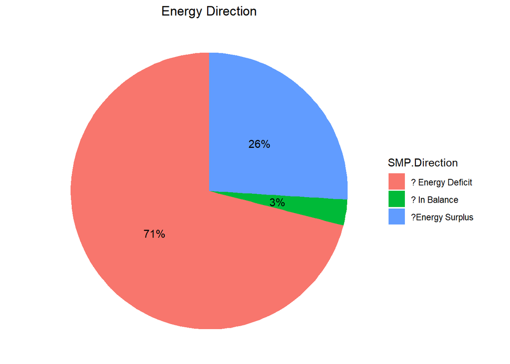

```r
ggplot(direction_df, aes(x="",y=Proportion, fill=SMP.Direction)) + geom_bar(stat="identity",width=1) + geom_text(aes(label = scales::percent(Proportion)), position = position_stack(vjust = 0.5)) + coord_polar("y") + theme_void() + ggtitle("Energy Direction") + theme(plot.title = element_text(hjust = 0.5))
```

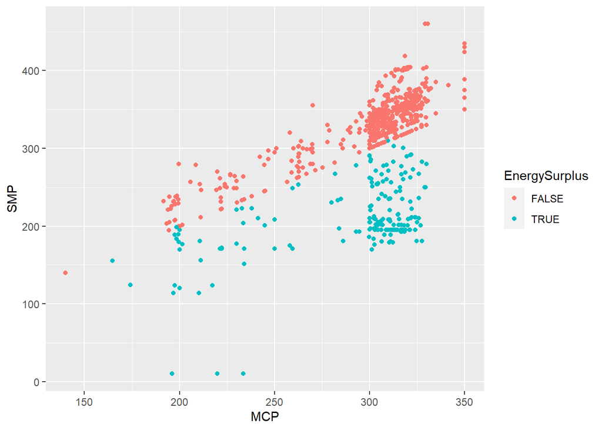

```r
ptfsmf %>% mutate(EnergySurplus = MCP>SMP)%>% ggplot()+geom_point(aes(x=MCP, y=SMP, color = EnergySurplus))
```

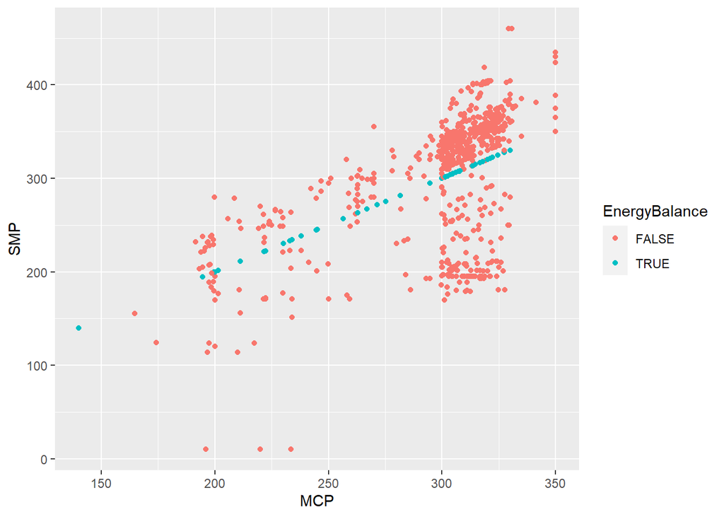

```r
ptfsmf %>% mutate(EnergyBalance = MCP==SMP)%>% ggplot()+geom_point(aes(x=MCP, y=SMP, color = EnergyBalance))
```

```
## # A tibble: 31 x 3
##    Day        AvgMCP AvgSMP
##    <date>      <dbl>  <dbl>
##  1 2020-07-01   320.   268.
##  2 2020-07-02   298.   357.
##  3 2020-07-03   317.   373.
##  4 2020-07-04   306.   321.
##  5 2020-07-05   258.   198.
##  6 2020-07-06   290.   307.
##  7 2020-07-07   307.   298.
##  8 2020-07-08   304.   191.
##  9 2020-07-09   288.   189.
## 10 2020-07-10   282.   292.
## # ... with 21 more rows
```

Energy deficit or excess energy was calculated according to the average MCP and SMP values during the day.

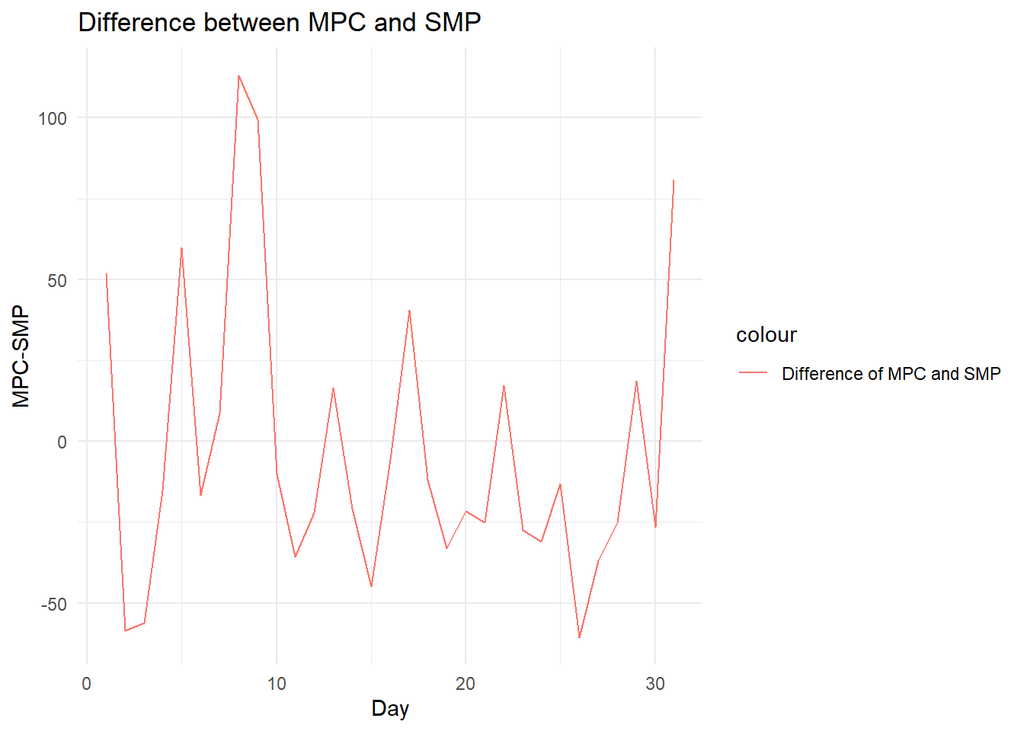